# Categorical variables

## Paired data

A study comparing the physician’s opinion and recommendations made by a clinical decision support system (`CDSS`), on the need of lipid lowering drugs (LLD) in 500 hypercholesterolemic patients

```r
d <- rio::import("https://raw.githubusercontent.com/acobos/Datasets/master/OptimCare.txt")
head(d)
```

```
  Case CDSS Physician
1    1   No       Yes
2    2  Yes       Yes
3    3   No       Yes
4    4  Yes       Yes
5    5  Yes       Yes
6    6   No        No
```

Both the `CDSS` and the `Physician` assessed the need of LLD (as `Yes` or `No`)

## McNemar’s test

Compares the two table margins, i.e., the *marginal homogeneity*

```r
library(mosaic)
x <- tally(CDSS ~ Physician, data=d)
addmargins(x)   # to show margins (Sum) of the contingency table
```

```
     Physician
CDSS   No Yes Sum
  No  209  57 266
  Yes   4 230 234
  Sum 213 287 500
```

Proportion of `Yes`:

- Physician: \(\quad\) 287 / 500 = 0.574
- CDSS: \(\qquad\) 234 / 500 = 0.468

## McNemar’s test

```r
mcnemar.test(x, correct = FALSE)
```

```
    McNemar's Chi-squared test

data:  x
McNemar's chi-squared = 46.049, df = 1, p-value = 1.153e-11
```

```r
mcnemar.test(x)
```

```
    McNemar's Chi-squared test with continuity correction

data:  x
McNemar's chi-squared = 44.328, df = 1, p-value = 2.777e-11
```

Use correction if number of discrepant results is low (e.g., < 10)

## Agreement: observed and expected (by chance)

```
$observed
     Physician
CDSS   No Yes
  No  209  57
  Yes   4 230

$expected
     Physician
CDSS     No   Yes
  No  113.3 152.7
  Yes  99.7 134.3
```

- \(P_o\) = (209 + 230) / 500 = 0.878
- \(P_e\) = (113.3 + 134.3) / 500 = 0.495

## Cohen’s kappa

\(\kappa = \frac{P_o - P_e}{1 - P_e} \quad\) = (0.878 - 0.495) / (1 - 0.495) = 0.758

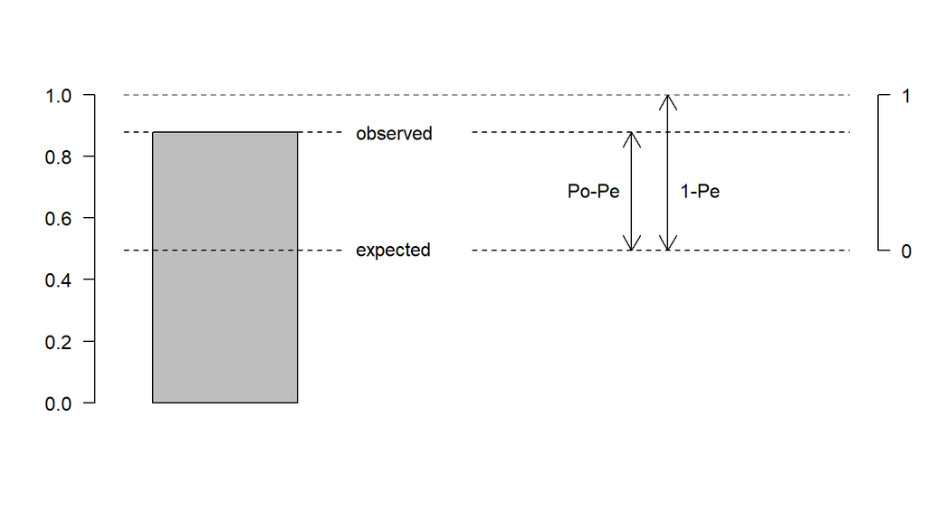

## Cohen’s kappa

Function `epi.kappa()` in package `epiR`

```r
library(epiR)
res <- epi.kappa(x)    # x is the contingency table computed previously
names(res)
```

```
[1] "prop.agree" "pabak"      "kappa"      "z"
```

```r
res$prop.agree         # proportions of observed and expected agreement
```

```
    obs      exp
1 0.878 0.495264
```

```r
res$kappa              # kappa (est) and CI (lower, upper)
```

```
        est         se    lower    upper
1 0.7582895 0.04372403 0.672592 0.843987
```

## Exercise

- BTA test vs cytology in diagnosis or follow-up of bladder cancer patients
- Reference standard: cystoscopy

```r
d <- rio::import("data/bta.xls")
head(d)
```

```
       bta cytology cystoscopy
1 Positive Negative   Negative
2 Negative Negative   Negative
3 Positive Positive   Positive
4 Negative Negative   Negative
5 Negative Negative   Negative
6 Positive Negative   Negative
```

## Exercise (cont.)

Using cystoscopy as the reference standard:

- Compute sensitivity and specificity of the BTA test
- Compute sensitivity and specificity of cytology
- Do these procedures have equal sensitivity?
- Do they have equal specificity?
- To what extend the results of both procedures agree?